# Pregunta 01

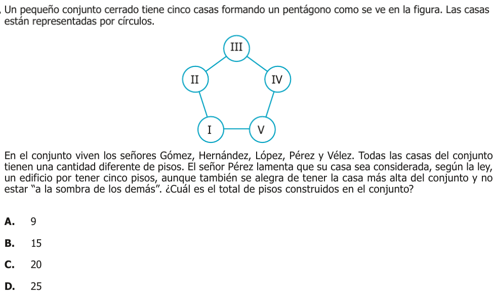

### Análisis

Para resolver este problema, debemos seguir una serie de pasos lógicos y matemáticos. Vamos a desglosar el problema y la solución paso a paso.

## Descripción del Problema

Un pequeño conjunto cerrado tiene cinco casas formando un pentágono como se ve en la figura. Las casas están representadas por círculos. En el conjunto viven los señores Gómez, Hernández, López, Pérez y Vélez. Todas las casas del conjunto tienen una cantidad diferente de pisos. El señor Pérez lamenta que su casa sea considerada, según la ley, un edificio por tener cinco pisos, aunque también se alegra de tener la casa más alta del conjunto y no estar “a la sombra de los demás”. ¿Cuál es el total de pisos construidos en el conjunto?

## Pasos para Resolver el Problema

### Paso 1: Identificar la Información Clave

1. Hay cinco casas formando un pentágono.
2. Cada casa tiene una cantidad diferente de pisos.
3. La casa del señor Pérez tiene cinco pisos y es la más alta.

### Paso 2: Asignar Números de Pisos a las Casas

Dado que cada casa tiene una cantidad diferente de pisos y la casa del señor Pérez tiene cinco pisos (la más alta), las otras casas deben tener 1, 2, 3 y 4 pisos.

### Paso 3: Sumar los Pisos

Sumamos los pisos de todas las casas:

$$1 + 2 + 3 + 4 + 5 = 15$$

## Conclusión

El total de pisos construidos en el conjunto es 15. Por lo tanto, la opción correcta es:

**B. 15**

## Resumen

- Identificamos que cada casa tiene una cantidad diferente de pisos.
- La casa del señor Pérez tiene cinco pisos, la más alta.
- Las otras casas tienen 1, 2, 3 y 4 pisos.
- Sumamos los pisos: $1 + 2 + 3 + 4 + 5 = 15$.

Por lo tanto, la respuesta correcta es la opción **B. 15**.

### Análisis de la Pregunta 2023-Matematicas-11-1-01, según SABER 11 ICFES

- Nivel de Desempeño: 2
- Competencia: Interpretación y Representación
  - Afirmación: Comprende y transforma la información cuantitativa y esquemática presentada en distintos formatos
  - Evidencia: Da cuenta de las características básicas de la información presentada en diferentes formatos como series, gráficas, tablas y esquemas
- Componente: Geométrico-Métrico
- Estándar Asociado: Uso representaciones geométricas para resolver y formular problemas en las matemáticas y en otras disciplinas
- ¿Qué evalúa?: La capacidad de interpretar información presentada en un diagrama geométrico (pentágono) y realizar operaciones aritméticas básicas
- Respuesta Correcta: B (15)
  - Justificación: Como cada casa tiene diferente número de pisos y la casa de Pérez tiene 5 pisos (siendo la más alta), las demás casas deben tener 1, 2, 3 y 4 pisos. Al sumar $1 + 2 + 3 + 4 + 5 = 15$ se obtiene el total de pisos.
- Distractores:
  - A (9): Suma incompleta o incorrecta de los pisos
  - C (20): Asume erróneamente que hay casas con igual número de pisos
  - D (25): Multiplica incorrectamente 5 casas × 5 pisos
- Contenidos Matemáticos Curriculares:
  - Geometría
  - Período 1
    - Geometría Básica
      - Interpretación de diagramas geométricos
- Genérico: Sí
- Eje Axial Disciplinar: Eje 1 - Diferentes a Series y Tablas: Interpretación y análisis de diagramas
- Tarea: Interpretar un diagrama geométrico para determinar la suma total de pisos en un conjunto de casas con restricciones dadas
- Grado: 6° - 7°